# Introduction

Basketball is a team sport in which two teams, most commonly of five players each, opposing one another on a rectangular court, compete with the primary objective of shooting a basketball (approximately 9.4 inches (24 cm) in diameter) through the defender’s hoop (a basket 18 inches (46 cm) in diameter mounted 10 feet (3.048 m) high to a backboard at each end of the court, while preventing the opposing team from shooting through their own hoop. A field goal is worth two points, unless made from behind the three-point line, when it is worth three. After a foul, timed play stops and the player fouled or designated to shoot a technical foul is given one, two or three one-point free throws. The team with the most points at the end of the game wins, but if regulation play expires with the score tied, an additional period of play (overtime) is mandated.

Players advance the ball by bouncing it while walking or running (dribbling) or by passing it to a teammate, both of which require considerable skill. On offense, players may use a variety of shots – the layup, the jump shot, or a dunk; on defense, they may steal the ball from a dribbler, intercept passes, or block shots; either offense or defense may collect a rebound, that is, a missed shot that bounces from rim or backboard. It is a violation to lift or drag one’s pivot foot without dribbling the ball, to carry it, or to hold the ball with both hands then resume dribbling.

In the sport of basketball, there are generally five players per team, each assigned to positions. Historically, these players have been assigned to positions defined by the role they play on the court, from a strategic point of view. Broadly speaking, the three main positions are guard, forward, and center, with the standard team featuring two guards, two forwards, and a center. Over time, as more specialized roles developed, each of the guards and forwards came to be differentiated, and today each of the five positions are known by unique names, each of which has also been assigned a number: point guard (PG) or 1, the shooting guard (SG) or 2, the small forward (SF) or 3, the power forward (PF) or 4, and the center (C) or 5.

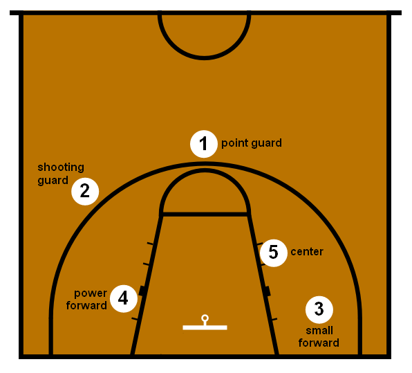

Basket Ball Positions.

The point guard is the “leader” of the team on the court. This position requires substantial ball-handling skills and the ability to facilitate the team during a play. The shooting guard, as the name implies, is often the best shooter, as well as being capable of shooting accurately from longer distances. The small forward often has an aggressive approach to the basket when handling the ball. The small forward is also known to make cuts to the basket in efforts to get open for shots. The power forward and the center make up the frontcourt, often acting as their team’s primary rebounders or shot blockers, or receiving passes to take inside shots. The center is typically the larger of the two.

## Objective

You have been tasked by the general manager of Chicago Bulls to find the best five starting players (one from each position) your team can afford. (Make sure you don’t use up all of your money on just these five players, you still need to fill a full team roster, but are just focused on finding five starting players here). You can choose players that were already playing for Chicago Bulls in 2018-19, you just need to prove that they are worth it.

## Importance

Once we have the top 5 players or the best players based on the statistics we have, the probability of winning the Chicago Bulls will increase.

# Reading and cleaning the raw data

## NBA Player Salaries

```
##   player_id  player_name   salary
## 1         1 Alex Abrines  3667645
## 2         2   Quincy Acy   213948
## 3         3 Steven Adams 24157304
## 4         4 Jaylen Adams   236854
## 5         5  Bam Adebayo  2955840
## 6         6    Deng Adel    77250
```

The above dataset has 3 columns, Id of the player, name and the salary of the player. Lets check for NA values

```
## [1] 0
```

There are 0 NA values in this dataset.

## NBA Player Statistics

```
##    player_name Pos Age  Tm  G GS   MP  FG FGA   FG. X3P X3PA  X3P. X2P X2PA
## 1 Alex Abrines  SG  25 OKC 31  2  588  56 157 0.357  41  127 0.323  15   30
## 2   Quincy Acy  PF  28 PHO 10  0  123   4  18 0.222   2   15 0.133   2    3
## 3 Jaylen Adams  PG  22 ATL 34  1  428  38 110 0.345  25   74 0.338  13   36
## 4 Steven Adams   C  25 OKC 80 80 2669 481 809 0.595   0    2 0.000 481  807
## 5  Bam Adebayo   C  21 MIA 82 28 1913 280 486 0.576   3   15 0.200 277  471
## 6    Deng Adel  SF  21 CLE 19  3  194  11  36 0.306   6   23 0.261   5   13
##    X2P.  eFG.  FT FTA   FT. ORB DRB TRB AST STL BLK TOV  PF  PTS
## 1 0.500 0.487  12  13 0.923   5  43  48  20  17   6  14  53  165
## 2 0.667 0.278   7  10 0.700   3  22  25   8   1   4   4  24   17
## 3 0.361 0.459   7   9 0.778  11  49  60  65  14   5  28  45  108
## 4 0.596 0.595 146 292 0.500 391 369 760 124 117  76 135 204 1108
## 5 0.588 0.579 166 226 0.735 165 432 597 184  71  65 121 203  729
## 6 0.385 0.389   4   4 1.000   3  16  19   5   1   4   6  13   32
```

The above dataset shows the statistics of each player.

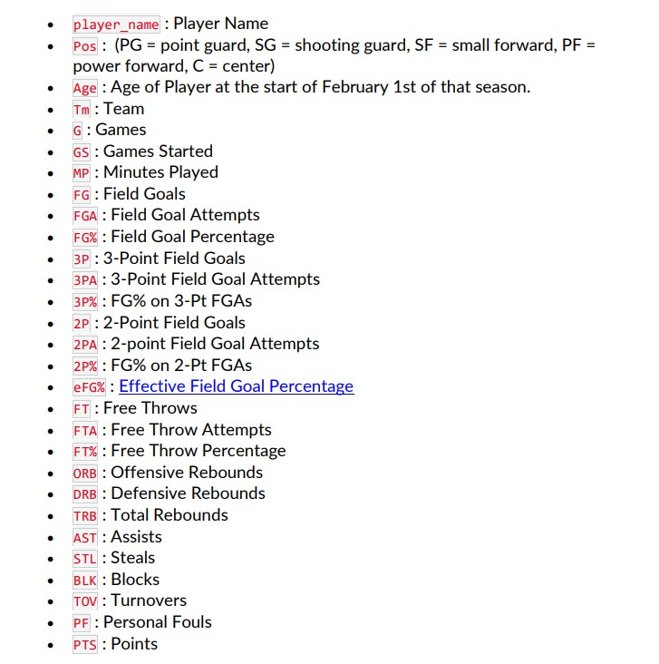

```
## [1] 117
```

There are 117 NA values in this dataset. We are going to replace NA values with 0 in the dataset.

```
## [1] 0
```

## NBA Team Statistics 1

```
##   ï..Rk                   Team  Age  W  L PW PL  MOV   SOS  SRS  ORtg  DRtg
## 1     1        Milwaukee Bucks 26.9 60 22 61 21 8.87 -0.82 8.04 113.8 105.2
## 2     2  Golden State Warriors 28.4 57 25 56 26 6.46 -0.04 6.42 115.9 109.5
## 3     3        Toronto Raptors 27.3 58 24 56 26 6.09 -0.60 5.49 113.1 107.1
## 4     4              Utah Jazz 27.3 50 32 54 28 5.26  0.03 5.28 110.9 105.7
## 5     5        Houston Rockets 29.2 53 29 53 29 4.77  0.19 4.96 115.5 110.7
## 6     6 Portland Trail Blazers 26.2 53 29 51 31 4.20  0.24 4.43 114.7 110.5
##   NRtg  Pace   FTr X3PAr   TS.  eFG. TOV. ORB. FT.FGA DRB.  X X.1 X.2
## 1  8.6 103.3 0.255 0.419 0.583 0.550 12.0 20.8  0.197 80.3 NA  NA  NA
## 2  6.4 100.9 0.227 0.384 0.596 0.565 12.6 22.5  0.182 77.1 NA  NA  NA
## 3  6.0 100.2 0.247 0.379 0.579 0.543 12.4 21.9  0.198 77.1 NA  NA  NA
## 4  5.2 100.3 0.295 0.394 0.572 0.538 13.4 22.9  0.217 80.3 NA  NA  NA
## 5  4.8  97.9 0.279 0.519 0.581 0.542 12.0 22.8  0.221 74.4 NA  NA  NA
## 6  4.2  99.1 0.258 0.339 0.568 0.528 12.1 26.6  0.210 77.9 NA  NA  NA
```

The above dataset shows the statistics of Teams

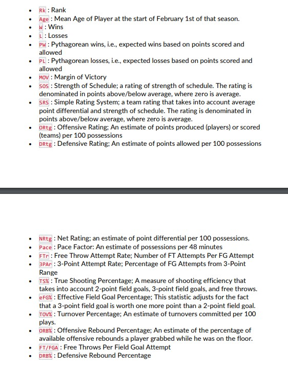

Team Statistics.

```
## [1] 90
```

There are 90 NA values in this dataset. We are going to replace NA values with 0 in the dataset.

```
## [1] 0
```

## NBA Team Statistics 2

```
##   ï..Rk                   Team  G    MP   FG  FGA   FG.  X3P X3PA  X3P.  X2P
## 1     1        Milwaukee Bucks 82 19780 3555 7471 0.476 1105 3134 0.353 2450
## 2     2  Golden State Warriors 82 19805 3612 7361 0.491 1087 2824 0.385 2525
## 3     3   New Orleans Pelicans 82 19755 3581 7563 0.473  842 2449 0.344 2739
## 4     4     Philadelphia 76ers 82 19805 3407 7233 0.471  889 2474 0.359 2518
## 5     5   Los Angeles Clippers 82 19830 3384 7178 0.471  821 2118 0.388 2563
## 6     6 Portland Trail Blazers 82 19855 3470 7427 0.467  904 2520 0.359 2566
##   X2PA  X2P.   FT  FTA   FT. ORB  DRB  TRB  AST STL BLK  TOV   PF  PTS
## 1 4337 0.565 1471 1904 0.773 762 3316 4078 2136 615 486 1137 1608 9686
## 2 4537 0.557 1339 1672 0.801 797 2990 3787 2413 625 525 1169 1757 9650
## 3 5114 0.536 1462 1921 0.761 909 2969 3878 2216 610 441 1215 1732 9466
## 4 4759 0.529 1742 2258 0.771 892 3025 3917 2207 606 432 1223 1745 9445
## 5 5060 0.507 1853 2340 0.792 796 2936 3732 1970 561 385 1193 1913 9442
## 6 4907 0.523 1558 1914 0.814 967 2968 3935 1887 546 413 1135 1669 9402
```

The above dataset shows the statistics of Teams.

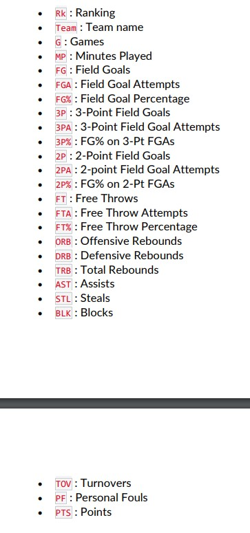

Team Statistics.

```
## [1] 0
```

There are 0 NA values in this dataset.

```
##   ï..team_id           team        salary
## 1          1         Miami  $153,171,497
## 2          2  Golden State  $146,291,276
## 3          3 Oklahoma City  $144,916,427
## 4          4       Toronto  $137,793,831
## 5          5     Milwaukee  $130,988,604
## 6          6      Portland  $130,256,600
```

The above dataset shows Team Payroll or the budget for the next season

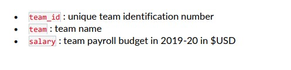

```
## [1] 0
```

There are 0 NA values in this dataset.

# Exploratory analysis

## Analyzing Team Statistics

Merging Team statistics 1 and Team Statistics 2 into one dataframe

```r
   df <- merge(nba_team_statistics_1, nba_team_statistics_2, by = "Team")
```

Correlation Matrix of all the variables.

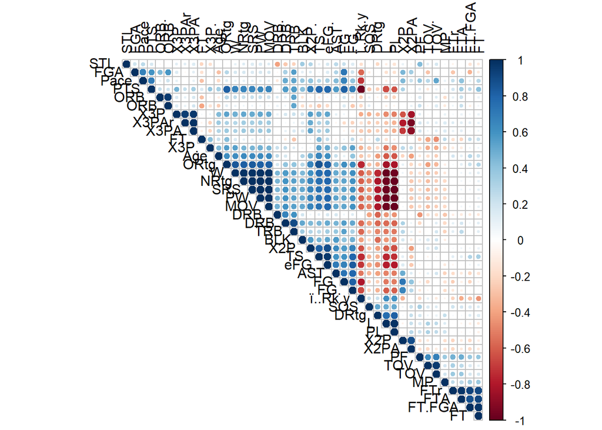

1. Plotting relationship between the Field goals and Points

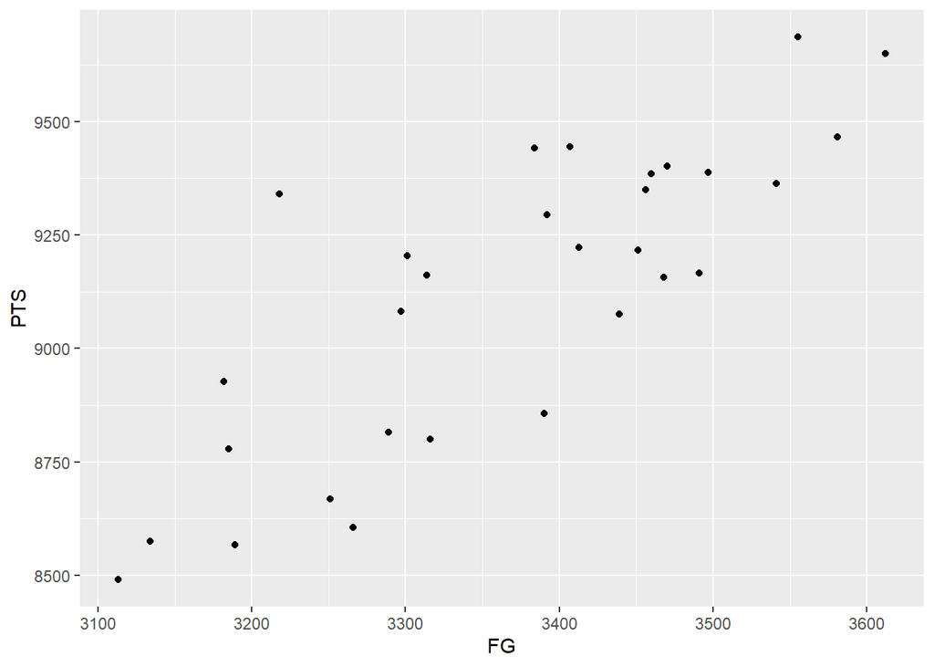

It shows the positive correlation between these two varaibles

2. Plotting relationship between the 3point field Goals and Points

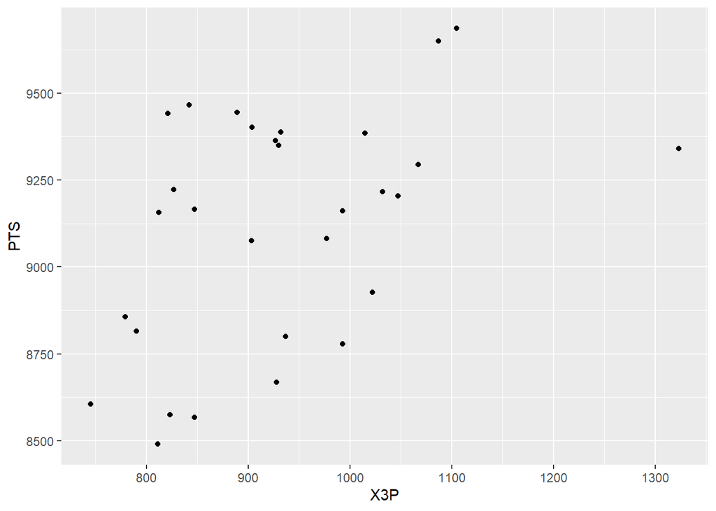

It shows the positive correlation between these two varaibles

3. Plotting relationship between the 2point field Goals and Points

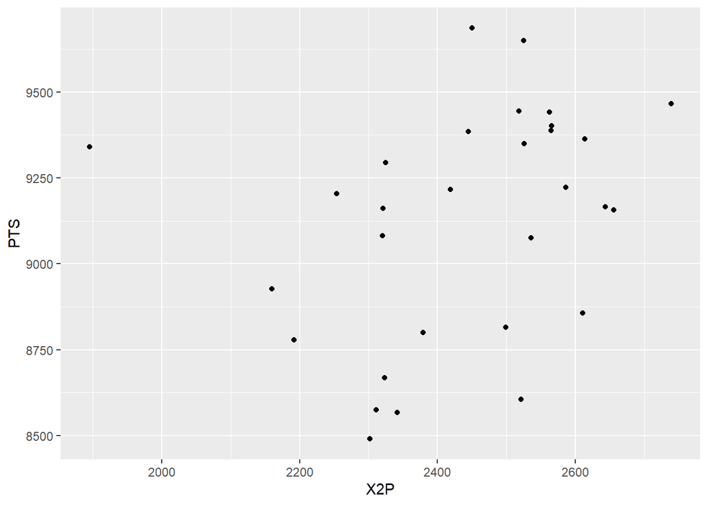

It shows the somewhat neutral relationship between the varaibles.

4. Plotting relationship between the Free Throws and Points

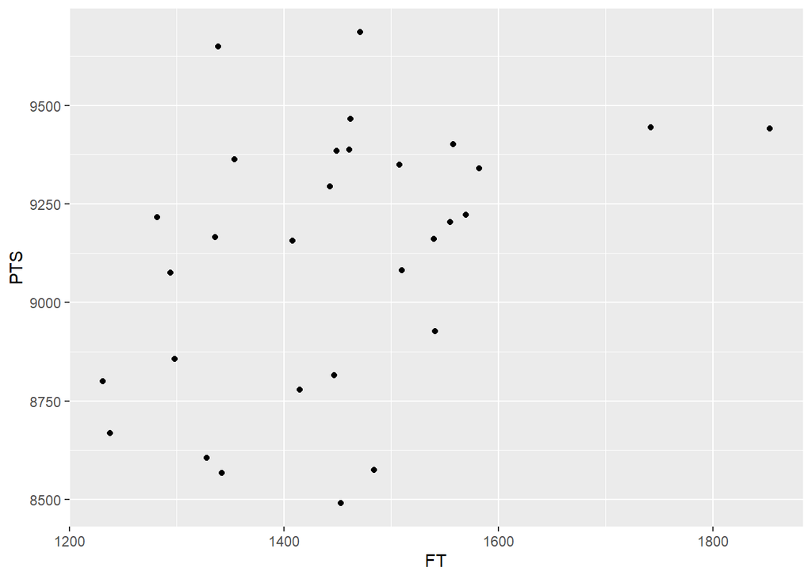

It shows the somewhat neutral relationship between the varaibles. But the Teams with more free throws have the chances of getting more goals in the game.

5. Plotting relationship between the Block and Points

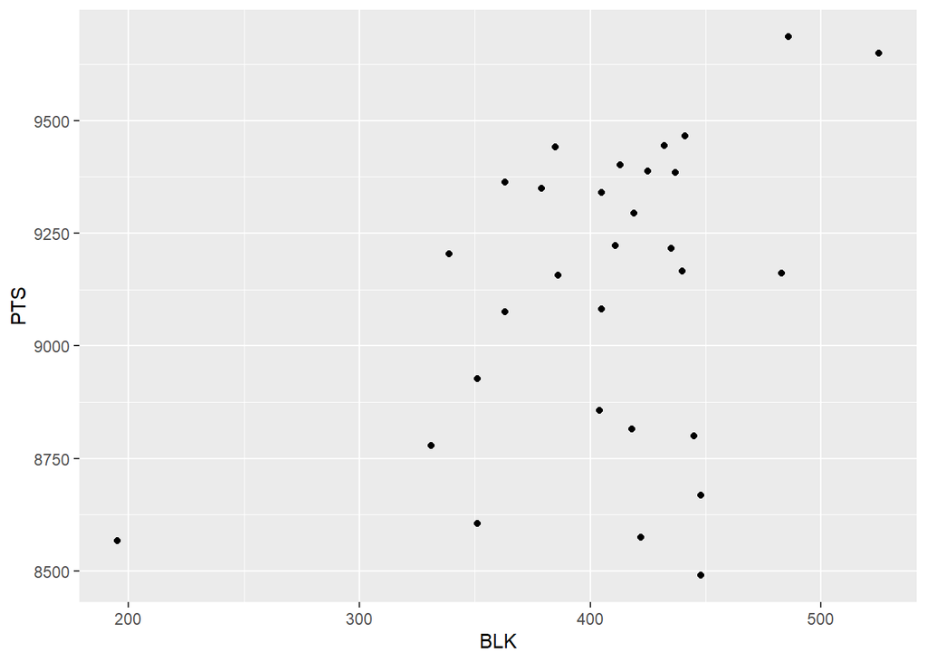

It shows the somewhat neutral relationship between the varaibles. But Blocks and points have direct relationship.

6. Plotting relationship between the Steals and Points

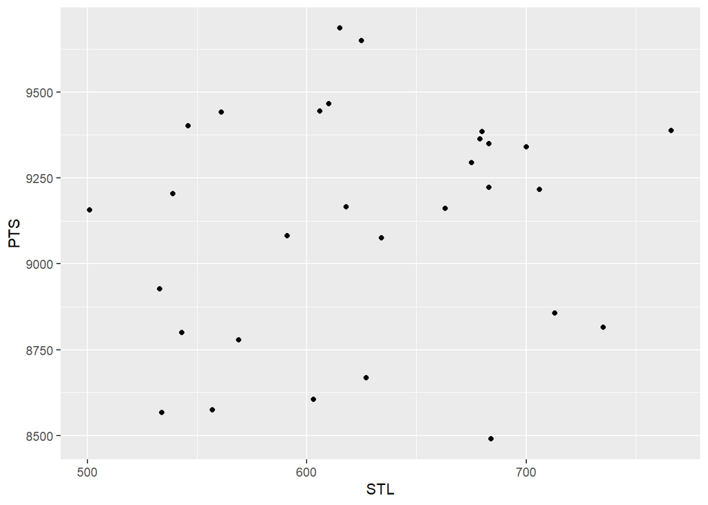

It shows the somewhat neutral relationship between the varaibles.

7. Plotting relationship between the Assists and Points

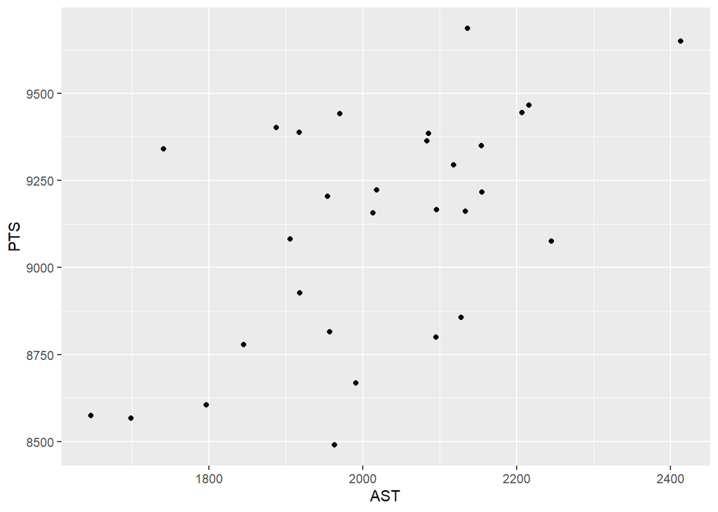

8. Plotting relationship between the Age and Points

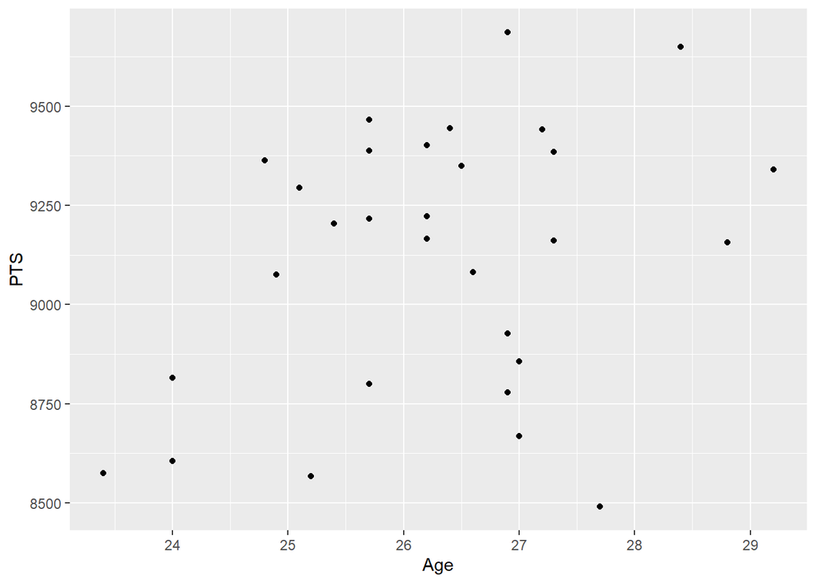

The Average age of the player should be between 25 to 27 years old.

9. Plotting relationship between the Turnover Percentage and Points

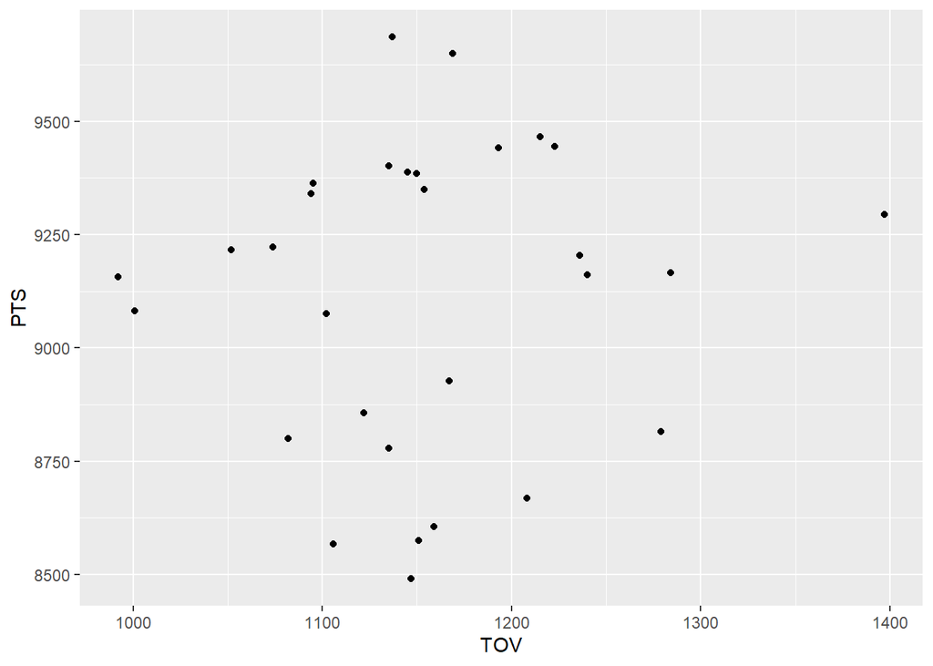

Turnover percentage has no specific relation with the POints.

10. Plotting relationship between the : Effective Field Goal Percentage and Points

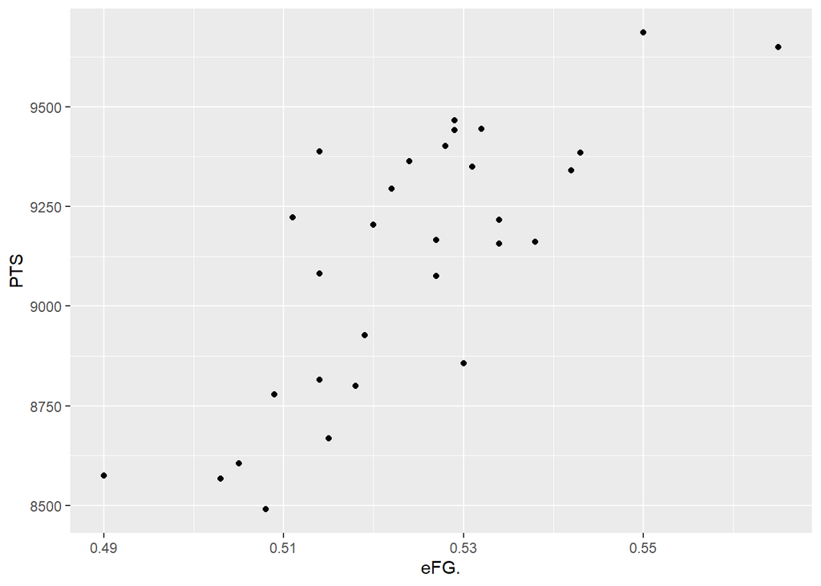

Effective Field Goal Percentage is one of the important variable as it shows the positive relation with the Points scored.

### From the above analysis we can say that Field goals, 3point field Goals, 2point field Goals,Free Throws, Block, Effective Field Goal Percentage are the important factors with decides the points of the team as well as the winning probability. Lets build the model.

Correlation Matrix of the analysed variables.

```
##        Age eFG.    FG   X3P   X2P    FT   AST   STL  BLK   TOV  PTS
## Age   1.00 0.61  0.10  0.43 -0.22  0.21  0.22 -0.02 0.30 -0.25 0.33
## eFG.  0.61 1.00  0.67  0.52  0.15  0.08  0.70  0.17 0.52  0.01 0.78
## FG    0.10 0.67  1.00  0.06  0.72 -0.05  0.73  0.22 0.40  0.00 0.82
## X3P   0.43 0.52  0.06  1.00 -0.64  0.09  0.10  0.12 0.21  0.01 0.46
## X2P  -0.22 0.15  0.72 -0.64  1.00 -0.10  0.49  0.09 0.17  0.00 0.31
## FT    0.21 0.08 -0.05  0.09 -0.10  1.00 -0.15 -0.12 0.00  0.17 0.40
## AST   0.22 0.70  0.73  0.10  0.49 -0.15  1.00  0.26 0.56  0.18 0.57
## STL  -0.02 0.17  0.22  0.12  0.09 -0.12  0.26  1.00 0.35  0.17 0.17
## BLK   0.30 0.52  0.40  0.21  0.17  0.00  0.56  0.35 1.00  0.19 0.41
## TOV  -0.25 0.01  0.00  0.01  0.00  0.17  0.18  0.17 0.19  1.00 0.08
## PTS   0.33 0.78  0.82  0.46  0.31  0.40  0.57  0.17 0.41  0.08 1.00
```

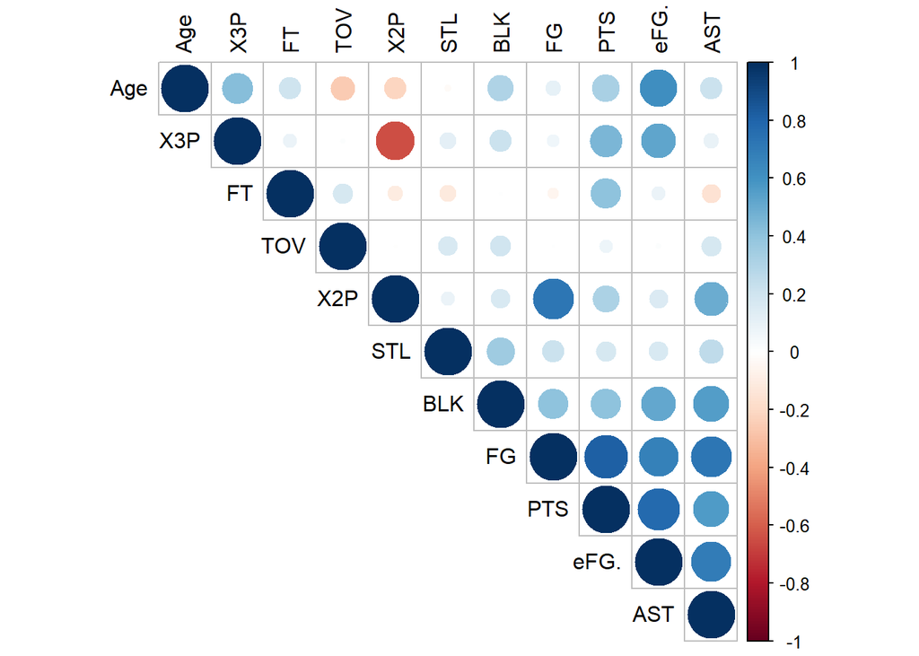

# Data modelling and results

## a) data modelling (e.g. creating a linear regression)

So if We run Linear Regression Model these variables to see how good they are in predicting the Points of model.

```
##
## Call:
## lm(formula = PTS ~ Age + FG + X3P + X2P + FT + BLK + STL + AST +
##     TOV + eFG., data = df)
##
## Residuals:
##        Min         1Q     Median         3Q        Max
## -2.463e-12 -7.862e-13 -7.890e-14  4.863e-13  6.756e-12
##
## Coefficients: (1 not defined because of singularities)
##               Estimate Std. Error    t value Pr(>|t|)
## (Intercept)  4.768e-12  1.991e-11  2.390e-01  0.81318
## Age          3.746e-13  4.828e-13  7.760e-01  0.44685
## FG           2.000e+00  5.445e-15  3.673e+14  < 2e-16 ***
## X3P          1.000e+00  4.446e-15  2.249e+14  < 2e-16 ***
## X2P                 NA         NA         NA       NA
## FT           1.000e+00  3.136e-15  3.189e+14  < 2e-16 ***
## BLK         -5.168e-15  8.485e-15 -6.090e-01  0.54932
## STL         -7.618e-16  6.165e-15 -1.240e-01  0.90288
## AST          3.208e-15  4.333e-15  7.400e-01  0.46777
## TOV          1.693e-14  5.567e-15  3.040e+00  0.00646 **
## eFG.        -1.203e-10  7.147e-11 -1.683e+00  0.10795
## ---
## Signif. codes:  0 '***' 0.001 '**' 0.01 '*' 0.05 '.' 0.1 ' ' 1
##
## Residual standard error: 2.077e-12 on 20 degrees of freedom
## Multiple R-squared:      1,  Adjusted R-squared:      1
## F-statistic: 8.408e+28 on 9 and 20 DF,  p-value: < 2.2e-16
```

## b) assumption checking

### Linearity of the data

The linearity assumption can be checked by inspecting the Residuals vs Fitted plot (1st plot):

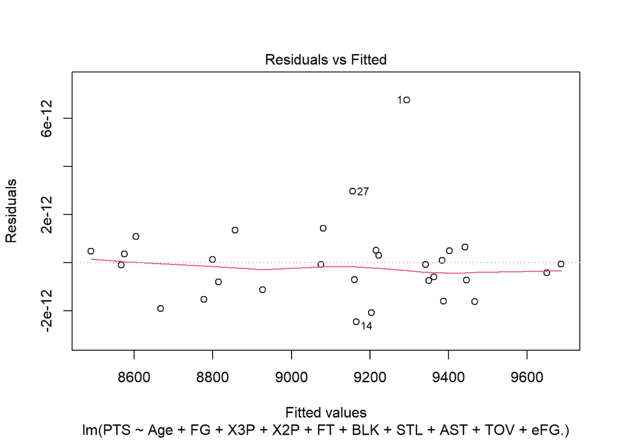

There is no pattern in the residual plot. This suggests that we can assume linear relationship between the predictors and the outcome variables.

### Homogeneity of variance

This assumption can be checked by examining the scale-location plot, also known as the spread-location plot.

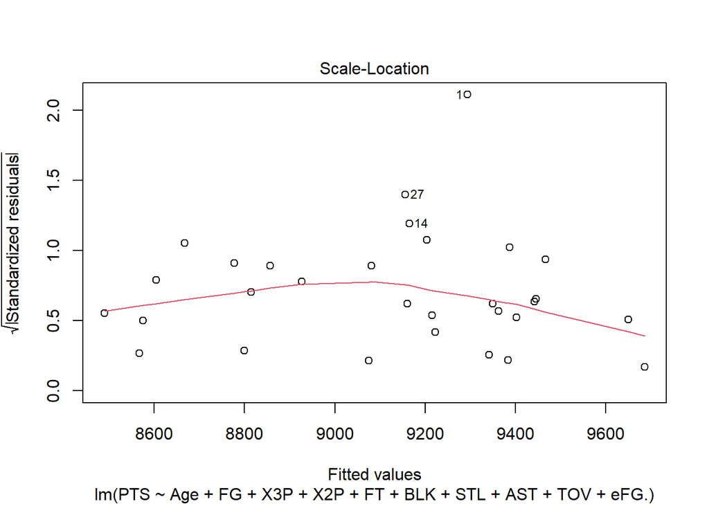

This plot shows if residuals are spread equally along the ranges of predictors. It’s good if you see a horizontal line with equally spread points.

### Normality of residuals

The QQ plot of residuals can be used to visually check the normality assumption. The normal probability plot of residuals should approximately follow a straight line.

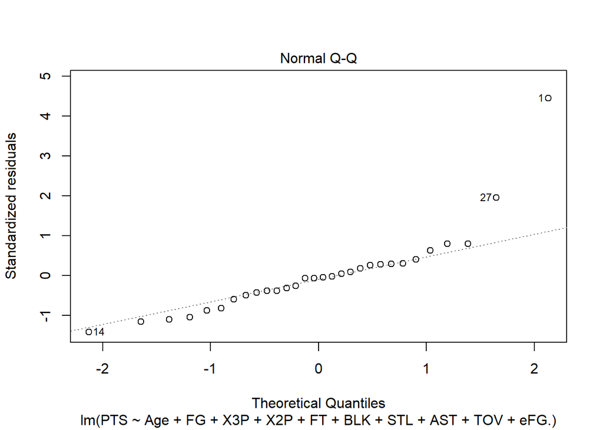

### Influential values

The following plots illustrate the Cook’s distance and the leverage of our model:

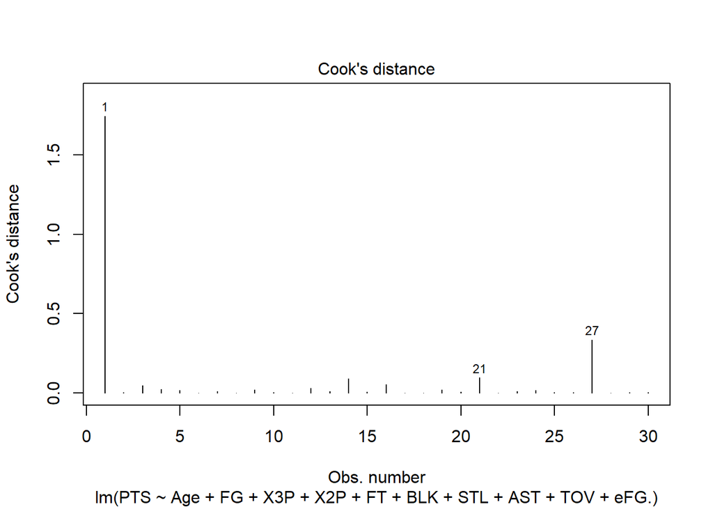

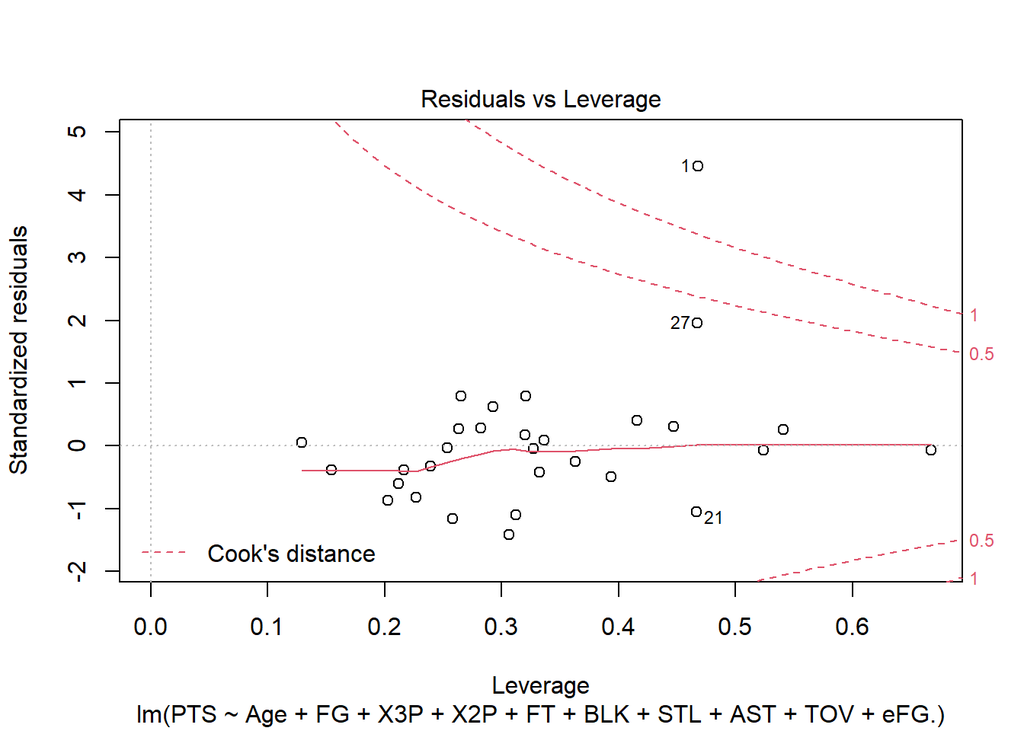

## c) model output and interpretation of Linear model

Here we can see some variables significant while some are insignificant variables. Significant of variables can be decided by the p value. If p value is less than 0.05 then we reject the null hypothesis and that where we accept the alternative hypothesis which is “h0 not equal to 0”.

# Player recommendations

Subset the dataset into position based dataframes.

Shooting Guard

```
##               player_name Pos Age  Tm  G GS  MP  FG FGA   FG. X3P X3PA  X3P.
## 1            Alex Abrines  SG  25 OKC 31  2 588  56 157 0.357  41  127 0.323
## 7  DeVaughn Akoon-Purcell  SG  25 DEN  7  0  22   3  10 0.300   0    4 0.000
## 9            Rawle Alkins  SG  21 CHI 10  1 120  13  39 0.333   3   12 0.250
## 10          Grayson Allen  SG  23 UTA 38  2 416  67 178 0.376  32   99 0.323
## 12           Kadeem Allen  SG  26 NYK 19  1 416  65 141 0.461  17   36 0.472
## 30           Dwayne Bacon  SG  23 CHO 43 13 759 122 257 0.475  38   87 0.437
##    X2P X2PA  X2P.  eFG. FT FTA   FT. ORB DRB TRB AST STL BLK TOV PF PTS
## 1   15   30 0.500 0.487 12  13 0.923   5  43  48  20  17   6  14 53 165
## 7    3    6 0.500 0.300  1   2 0.500   1   3   4   6   2   0   2  4   7
## 9   10   27 0.370 0.372  8  12 0.667  11  15  26  13   1   0   8  7  37
## 10  35   79 0.443 0.466 45  60 0.750   3  20  23  25   6   6  33 47 211
## 12  48  105 0.457 0.521 42  54 0.778   8  43  51  76  16   4  26 46 189
## 30  84  170 0.494 0.549 34  46 0.739   8  81  89  47  12   5  18 72 316
```

Power Forward

```
##              player_name Pos Age  Tm  G GS   MP  FG  FGA   FG. X3P X3PA  X3P.
## 2             Quincy Acy  PF  28 PHO 10  0  123   4   18 0.222   2   15 0.133
## 13       Al-Farouq Aminu  PF  28 POR 81 81 2292 257  593 0.433  96  280 0.343
## 16         Ryan Anderson  PF  30 MIA 10  0   44   2    9 0.222   2    6 0.333
## 17         Ryan Anderson  PF  30 PHO 15  8  278  19   60 0.317   7   34 0.206
## 18         Ryan Anderson  PF  30 TOT 25  8  322  21   69 0.304   9   40 0.225
## 20 Giannis Antetokounmpo  PF  24 MIL 72 72 2358 721 1247 0.578  52  203 0.256
##    X2P X2PA  X2P.  eFG.  FT FTA   FT. ORB DRB TRB AST STL BLK TOV  PF  PTS
## 2    2    3 0.667 0.278   7  10 0.700   3  22  25   8   1   4   4  24   17
## 13 161  313 0.514 0.514 150 173 0.867 112 498 610 104  68  33  72 143  760
## 16   0    3 0.000 0.333   1   2 0.500   4   5   9   2   1   0   2   2    7
## 17  12   26 0.462 0.375  11  14 0.786  14  31  45  17   3   1  12  23   56
## 18  12   29 0.414 0.370  12  16 0.750  18  36  54  19   4   1  14  25   63
## 20 669 1044 0.641 0.599 500 686 0.729 159 739 898 424  92 110 268 232 1994
```

Center

```
##          player_name Pos Age  Tm  G GS   MP  FG  FGA   FG. X3P X3PA  X3P. X2P
## 4       Steven Adams   C  25 OKC 80 80 2669 481  809 0.595   0    2 0.000 481
## 5        Bam Adebayo   C  21 MIA 82 28 1913 280  486 0.576   3   15 0.200 277
## 8  LaMarcus Aldridge   C  33 SAS 81 81 2687 684 1319 0.519  10   42 0.238 674
## 11     Jarrett Allen   C  20 BRK 80 80 2096 335  568 0.590   6   45 0.133 329
## 19      Ike Anigbogu   C  20 IND  3  0    6   0    3 0.000   0    0 0.000   0
## 29     Deandre Ayton   C  20 PHO 71 70 2183 509  870 0.585   0    4 0.000 509
##    X2PA  X2P.  eFG.  FT FTA   FT. ORB DRB TRB AST STL BLK TOV  PF  PTS
## 4   807 0.596 0.595 146 292 0.500 391 369 760 124 117  76 135 204 1108
## 5   471 0.588 0.579 166 226 0.735 165 432 597 184  71  65 121 203  729
## 8  1277 0.528 0.522 349 412 0.847 251 493 744 194  43 107 144 179 1727
## 11  523 0.629 0.595 197 278 0.709 191 481 672 110  43 120 103 184  873
## 19    3 0.000 0.000   0   0 0.000   1   2   3   1   0   1   1   0    0
## 29  866 0.588 0.585 141 189 0.746 223 506 729 125  61  67 126 209 1159
```

Small Forward

```
##        player_name Pos Age  Tm  G GS   MP  FG FGA   FG. X3P X3PA  X3P. X2P X2PA
## 6        Deng Adel  SF  21 CLE 19  3  194  11  36 0.306   6   23 0.261   5   13
## 14 Justin Anderson  SF  25 ATL 48  4  463  64 157 0.408  24   77 0.312  40   80
## 15   Kyle Anderson  SF  25 MEM 43 40 1281 150 276 0.543   9   34 0.265 141  242
## 23      OG Anunoby  SF  21 TOR 67  6 1352 183 404 0.453  67  202 0.332 116  202
## 25    Trevor Ariza  SF  33 PHO 26 26  884  86 227 0.379  50  139 0.360  36   88
## 26    Trevor Ariza  SF  33 WAS 43 43 1465 208 509 0.409  95  295 0.322 113  214
##     X2P.  eFG. FT FTA   FT. ORB DRB TRB AST STL BLK TOV  PF PTS
## 6  0.385 0.389  4   4 1.000   3  16  19   5   1   4   6  13  32
## 14 0.500 0.484 26  35 0.743  24  60  84  23  22  13  23  48 178
## 15 0.583 0.560 37  64 0.578  48 203 251 128  54  37  58 112 346
## 23 0.574 0.536 36  62 0.581  58 139 197  47  46  22  55 140 469
## 25 0.409 0.489 36  43 0.837  16 129 145  87  38   8  39  44 258
## 26 0.528 0.502 94 121 0.777  34 192 226 165  53  13  67  86 605
```

Point Guard

```
##         player_name Pos Age  Tm  G GS   MP  FG FGA   FG. X3P X3PA  X3P. X2P
## 3      Jaylen Adams  PG  22 ATL 34  1  428  38 110 0.345  25   74 0.338  13
## 24 Ryan Arcidiacono  PG  24 CHI 81 32 1961 187 418 0.447  81  217 0.373 106
## 28      DJ Augustin  PG  31 ORL 81 81 2269 318 677 0.470 131  311 0.421 187
## 35     Wade Baldwin  PG  22 POR 16  0   94  10  33 0.303   2    9 0.222   8
## 36       Lonzo Ball  PG  21 LAL 47 45 1423 185 456 0.406  75  228 0.329 110
## 38         JJ Barea  PG  34 DAL 38  0  752 161 385 0.418  38  128 0.297 123
##    X2PA  X2P.  eFG.  FT FTA   FT. ORB DRB TRB AST STL BLK TOV  PF PTS
## 3    36 0.361 0.459   7   9 0.778  11  49  60  65  14   5  28  45 108
## 24  201 0.527 0.544  89 102 0.873  27 192 219 269  65   4  63 171 544
## 28  366 0.511 0.566 181 209 0.866  41 162 203 426  52   4 128 115 948
## 35   24 0.333 0.333   8  11 0.727   2  13  15  12   1   2  14  11  30
## 36  228 0.482 0.488  20  48 0.417  54 197 251 255  69  19 103 114 465
## 38  257 0.479 0.468  55  78 0.705  13  82  95 211  22   1  72  50 415
```

There are duplicates in the player statistics, lets keep the best entry with the maximum points.

### Plotting - Shooting Guard DataFrame Analysis

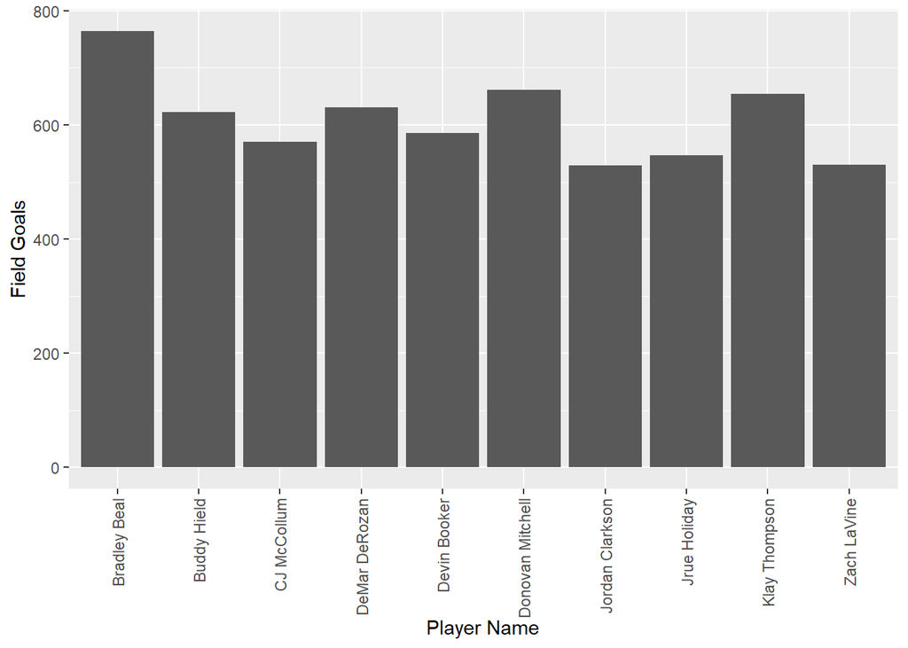

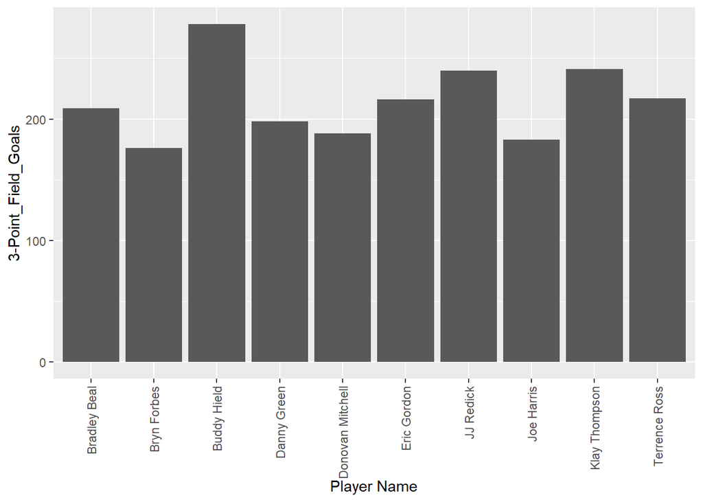

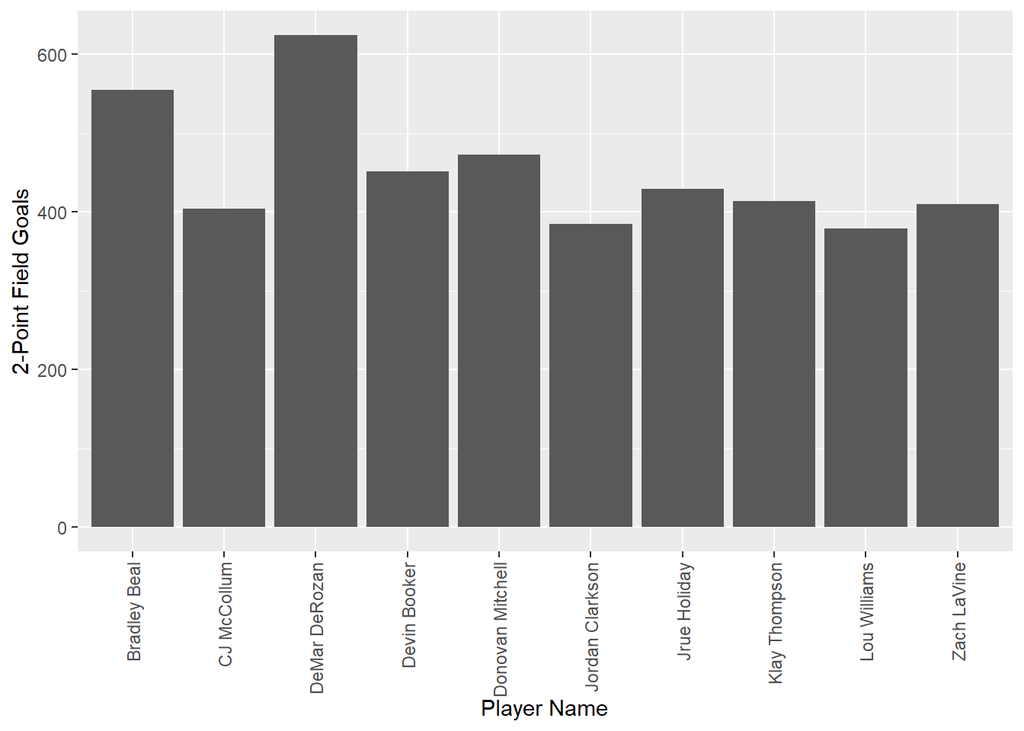

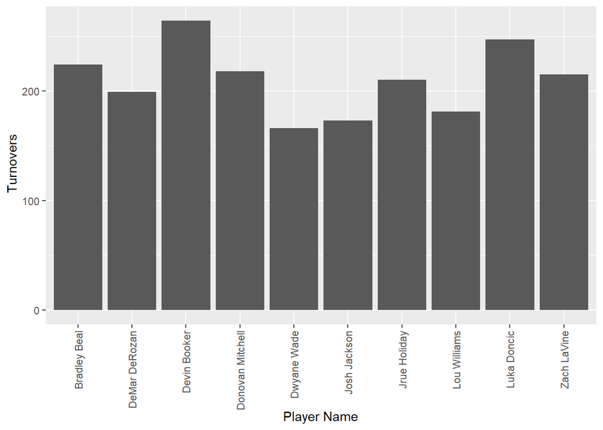

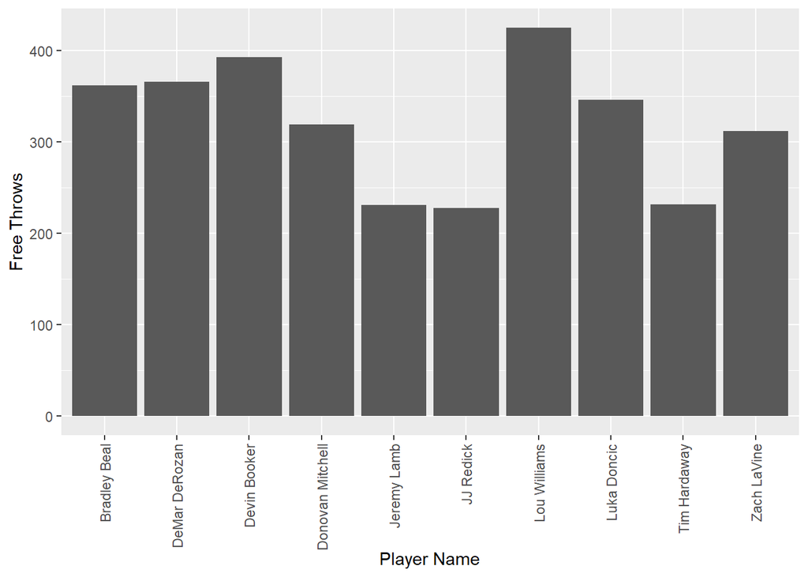

### Plotting - Power Forward DataFrame Analysis

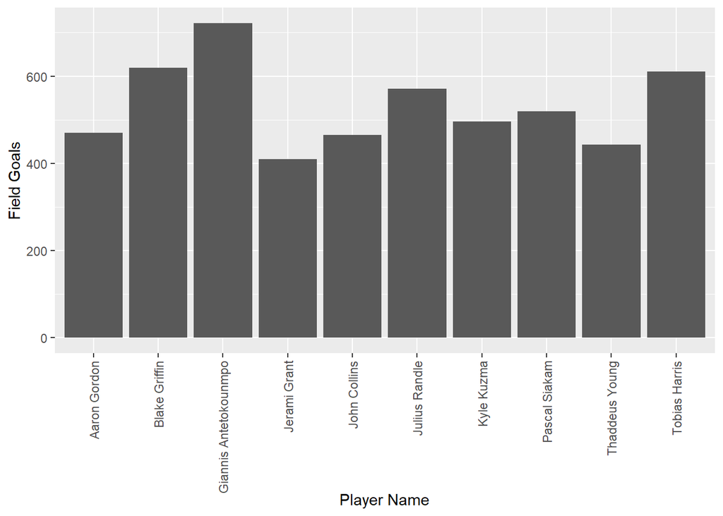

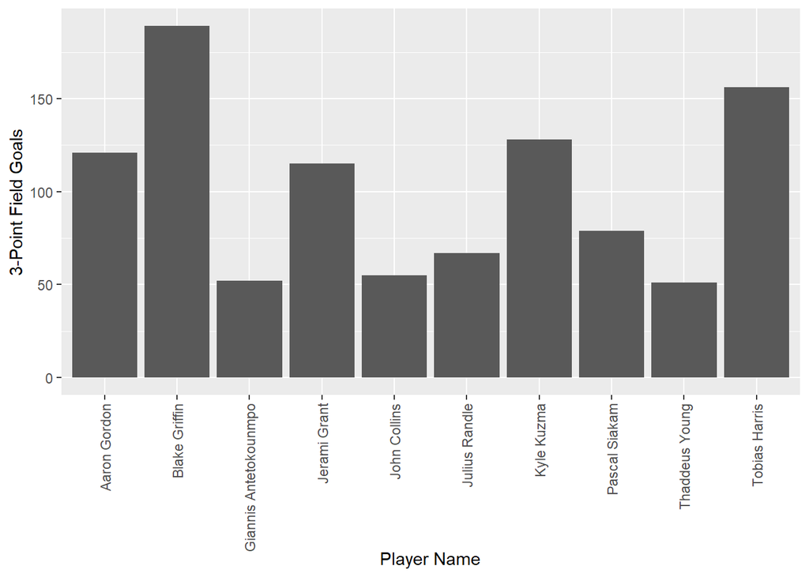

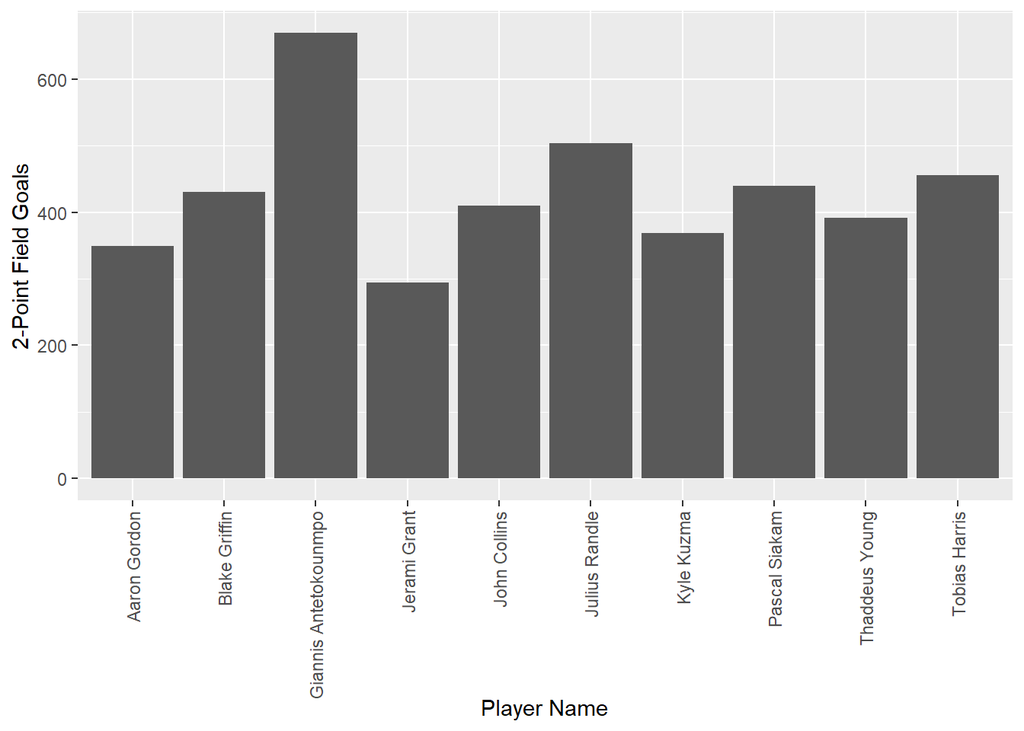

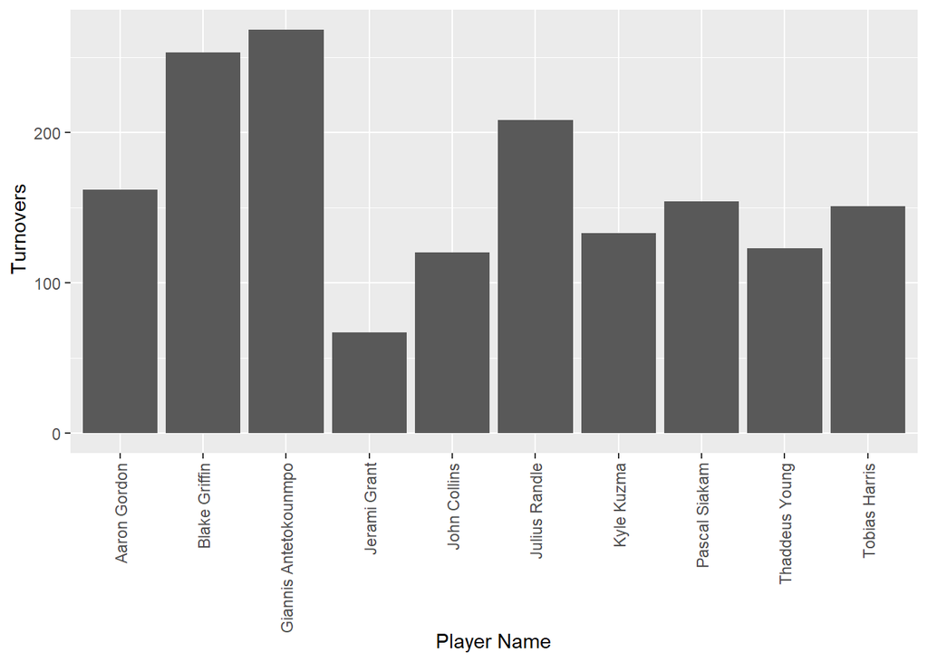

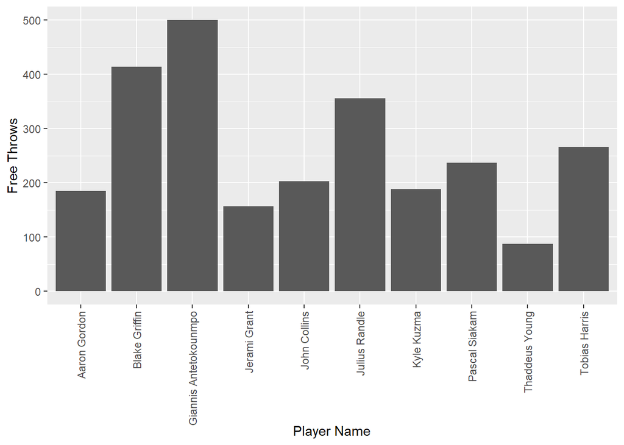